# MAVE QC Report

MAVEQC-v0.2.2

2023-08-31 12:02:59

## 1. Introduction

MAVEQC is a flexible R-package that provides QC analysis of Saturation Genome Editing (SGE) experimental data. Available under GPL 3.0 from https://github.com/wtsi-hgi/MAVEQC

## 2. Plasmid QC

Displays QC plots and statistics for all samples for QC.

### 2.1. Sample Sheet

| sample_name | library_independent_count | library_dependent_count | valiant_meta | vep_anno | adapt5 | adapt3 | per_r1_adaptor | per_r2_adaptor | library_name | library_type |
| --- | --- | --- | --- | --- | --- | --- | --- | --- | --- | --- |
| cmdc1_d0_r1 | Rep1_CMDC1_Day0.query_counts.tsv.gz | Rep1_CMDC1_Day0.lib_counts.tsv.gz | cmdc1_meta.csv.gz | NA | GGCAGGATGGATTCTGAGCAGAGCC | TTCAGTGTGCCTGAAAGTGGTTTGC | 0.318267 | NA | chr14_95103285_95103579_minus | plasmid |
| cmdc3_d0_r1 | Rep1_CMDC3_Day0.query_counts.tsv.gz | Rep1_CMDC3_Day0.lib_counts.tsv.gz | cmdc3_meta.csv.gz | NA | AAACAGCAGCTATGTTTCCCCTCCT | CTGCATATGAATGGAAAATGCCCAA | 0.321144 | NA | chr14_95096466_95096760_minus | plasmid |
| hgch1_d0_r1 | Rep1_HGCH1_Day0.query_counts.tsv.gz | Rep1_HGCH1_Day0.lib_counts.tsv.gz | hgch1_meta.csv.gz | NA | ATTCACGTTATGCTGTCCAATCTCT | GAAATCTAAAATTACCTTCCCAGGG | 0.315031 | NA | CHD7_exon16 | plasmid |
| hgch2_d0_r1 | Rep1_HGCH2_Day0.query_counts.tsv.gz | Rep1_HGCH2_Day0.lib_counts.tsv.gz | hgch2_meta.csv.gz | NA | AATGATACGGCGACCACCGAGGCCTCCTTGTTCACACTGATGTTT | AATGCACAAGAAAGTCCTGATGCCTTCGTATGCCGTCTTCTGCTTG | 0.331205 | NA | CHD7_exon17 | plasmid |
| hgeh1_d0_r1 | Rep1_HGEH1_Day0.query_counts.tsv.gz | Rep1_HGEH1_Day0.lib_counts.tsv.gz | hgeh1_meta.csv.gz | NA | AATGATACGGCGACCACCGAGAACCAGTTTTCTTCCTCATTTCAG | CCTGGTGTCATTTCTGGGACGGAGGTCGTATGCCGTCTTCTGCTTG | 0.328052 | NA | EHMT1_exon24 | plasmid |
| hgeh2_d0_r1 | Rep1_HGEH2_Day0.query_counts.tsv.gz | Rep1_HGEH2_Day0.lib_counts.tsv.gz | hgeh2_meta.csv.gz | NA | AATGATACGGCGACCACCGAATGTTCTTCTGGTGTGCCCTGCTCT | ACTTGTGAACTGTAAAACCTGAATGTCGTATGCCGTCTTCTGCTTG | 0.330669 | NA | EHMT1_exon25 | plasmid |
| hgkd1_d0_r1 | Rep1_HGKD1_Day0.query_counts.tsv.gz | Rep1_HGKD1_Day0.lib_counts.tsv.gz | hgkd1_meta.csv.gz | NA | AGCATGTCTAAGGCATATCAGAGCA | TGAGCTGGCAGAGGGGCCATTGTGG | 0.320588 | NA | KMT2D_exon52 | plasmid |
| hgkd2_d0_r1 | Rep1_HGKD2_Day0.query_counts.tsv.gz | Rep1_HGKD2_Day0.lib_counts.tsv.gz | hgkd2_meta.csv.gz | NA | AATGATACGGCGACCACCGAGGGAAAGGCAGGAGAAATGAAGTAC | GGATTTAGTGGTCCCTGAGAGTGGCTCGTATGCCGTCTTCTGCTTG | 0.328408 | NA | KMT2D_exon53 | plasmid |
| hgsm2_d0_r1 | Rep1_HGSM2_Day0.query_counts.tsv.gz | Rep1_HGSM2_Day0.lib_counts.tsv.gz | hgsm2_meta.csv.gz | NA | AATGATACGGCGACCACCGACGCTGACCCTGTTCTCCTCTGTGCC | AAGGAAGGGGGTGCCTGCAAAACCTTCGTATGCCGTCTTCTGCTTG | 0.330412 | NA | SMARCA4_exon25 | plasmid |
| hgsm3_d0_r1 | Rep1_HGSM3_Day0.query_counts.tsv.gz | Rep1_HGSM3_Day0.lib_counts.tsv.gz | hgsm3_meta.csv.gz | NA | CTGACTGGCACCTCTTCCCCCAGGA | CCCCGACCCCTCCCCAGCGTGAATG | 0.318769 | NA | SMARCA4_exon26 | plasmid |

### 2.2. Run Sample QC

#### 2.2.1. Read Length Distrubtion

Displays the percentage of reads for each sample, based on 50 nucleotide increments.

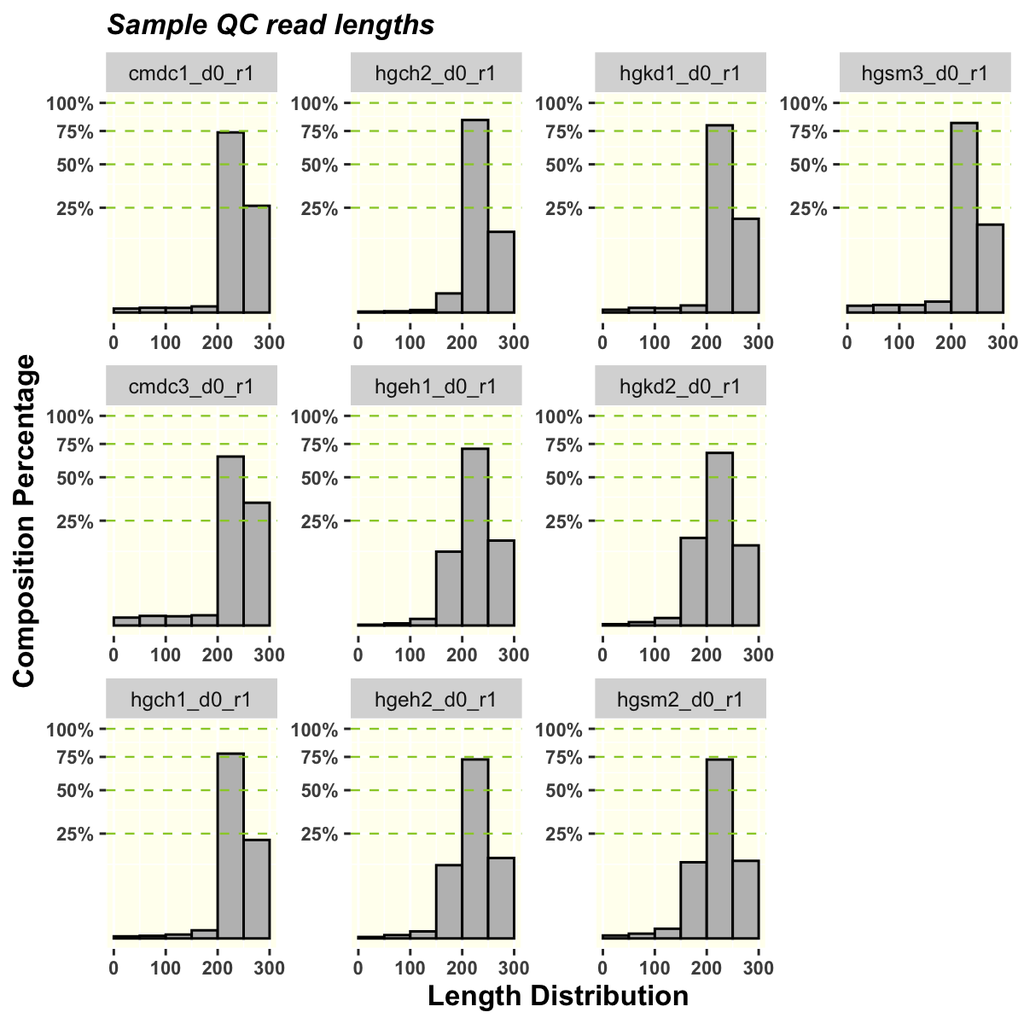

| Group | Sample | Total Reads | % 0 ~ 50 | % 50 ~ 100 | % 100 ~ 150 | % 150 ~ 200 | % 200 ~ 250 | % 250 ~ 300 | Pass Threshold | Pass |
| --- | --- | --- | --- | --- | --- | --- | --- | --- | --- | --- |
| chr14_95103285_95103579_minus | cmdc1_d0_r1 | 4991632 | 0 | 0.1 | 0 | 0.1 | 73.8 | 25.9 | 90 | True |
| chr14_95103285_95103579_minus | cmdc3_d0_r1 | 3516587 | 0.1 | 0.2 | 0.2 | 0.2 | 64.9 | 34.3 | 90 | True |
| chr14_95103285_95103579_minus | hgch1_d0_r1 | 3177682 | 0 | 0 | 0 | 0.2 | 77.7 | 22.1 | 90 | True |
| chr14_95103285_95103579_minus | hgch2_d0_r1 | 5190123 | 0 | 0 | 0 | 0.8 | 84.3 | 14.8 | 90 | True |
| chr14_95103285_95103579_minus | hgeh1_d0_r1 | 5947206 | 0 | 0 | 0.1 | 12.4 | 71.1 | 16.4 | 90 | False |
| chr14_95103285_95103579_minus | hgeh2_d0_r1 | 4129231 | 0 | 0 | 0.1 | 12.2 | 72.9 | 14.7 | 90 | False |
| chr14_95103285_95103579_minus | hgkd1_d0_r1 | 4914851 | 0 | 0.1 | 0 | 0.1 | 79.8 | 20 | 90 | True |
| chr14_95103285_95103579_minus | hgkd2_d0_r1 | 4998595 | 0 | 0 | 0.1 | 17.5 | 67.8 | 14.6 | 90 | False |
| chr14_95103285_95103579_minus | hgsm2_d0_r1 | 5287767 | 0 | 0.1 | 0.2 | 13.2 | 72.8 | 13.7 | 90 | False |
| chr14_95103285_95103579_minus | hgsm3_d0_r1 | 4211698 | 0.1 | 0.1 | 0.1 | 0.3 | 81.8 | 17.6 | 90 | True |

#### 2.2.2. Missing Variants

Missing variants in the library

| Group | Sample | Library Sequences | Missing Library Sequences | % Missing Library Sequences | Pass Threshold | Pass |
| --- | --- | --- | --- | --- | --- | --- |
| chr14_95103285_95103579_minus | cmdc1_d0_r1 | 2385 | 70 | 2.9 | 1 | False |
| chr14_95103285_95103579_minus | cmdc3_d0_r1 | 2476 | 48 | 1.9 | 1 | False |
| chr14_95103285_95103579_minus | hgch1_d0_r1 | 2144 | 8 | 0.4 | 1 | True |
| chr14_95103285_95103579_minus | hgch2_d0_r1 | 2022 | 37 | 1.8 | 1 | False |
| chr14_95103285_95103579_minus | hgeh1_d0_r1 | 1037 | 1 | 0.1 | 1 | True |
| chr14_95103285_95103579_minus | hgeh2_d0_r1 | 980 | 2 | 0.2 | 1 | True |
| chr14_95103285_95103579_minus | hgkd1_d0_r1 | 2429 | 48 | 2 | 1 | False |
| chr14_95103285_95103579_minus | hgkd2_d0_r1 | 923 | 3 | 0.3 | 1 | True |
| chr14_95103285_95103579_minus | hgsm2_d0_r1 | 1739 | 24 | 1.4 | 1 | False |
| chr14_95103285_95103579_minus | hgsm3_d0_r1 | 2338 | 48 | 2.1 | 1 | False |

| name | length | count | unique | sample |
| --- | --- | --- | --- | --- |
| ENST00000343455.8.ENSG00000100697.16_chr14:95096750_A>T_gnomad_v3_rc | 295 | 0 | 1 | SGE_1121589941_Rep1_CMDC3_Day0 |
| ENST00000343455.8.ENSG00000100697.16_chr14:95096489_95096491_AGA>GTT_aa_rc | 295 | 0 | 1 | SGE_1121589941_Rep1_CMDC3_Day0 |
| ENST00000343455.8.ENSG00000100697.16_chr14:95096489_95096491_AGA>CTT_aa_rc | 295 | 0 | 1 | SGE_1121589941_Rep1_CMDC3_Day0 |
| ENST00000343455.8.ENSG00000100697.16_chr14:95096489_95096491_AGA>GGT_aa_rc | 295 | 0 | 0 | SGE_1121589941_Rep1_CMDC3_Day0 |
| ENST00000343455.8.ENSG00000100697.16_chr14:95096489_95096491_AGA>GGT_snvre_rc | 295 | 0 | 0 | SGE_1121589941_Rep1_CMDC3_Day0 |
| ENST00000343455.8.ENSG00000100697.16_chr14:95096489_95096491_AGA>GCT_snvre_rc | 295 | 0 | 1 | SGE_1121589941_Rep1_CMDC3_Day0 |
| ENST00000343455.8.ENSG00000100697.16_chr14:95096489_95096491_AGA>ACT_snvre_rc | 295 | 0 | 1 | SGE_1121589941_Rep1_CMDC3_Day0 |
| ENST00000343455.8.ENSG00000100697.16_chr14:95096489_95096491_AGA>GAT_aa_rc | 295 | 0 | 1 | SGE_1121589941_Rep1_CMDC3_Day0 |
| ENST00000343455.8.ENSG00000100697.16_chr14:95096489_95096491_AGA>CAT_aa_rc | 295 | 0 | 1 | SGE_1121589941_Rep1_CMDC3_Day0 |
| ENST00000343455.8.ENSG00000100697.16_chr14:95096489_95096491_AGA>GTG_aa_rc | 295 | 0 | 1 | SGE_1121589941_Rep1_CMDC3_Day0 |

[output cut: 354 more lines]

#### 2.2.3. Total Reads

Displays the total number of reads per sample. Filtering based on 1-dimensional Kmean clustering that excludes unique sequences with low read counts.

- **Accepted reads**: Total read count for all unique sequences with sufficient reads.
- **Excluded reads**: Total read count for all unique sequences with insufficient reads.

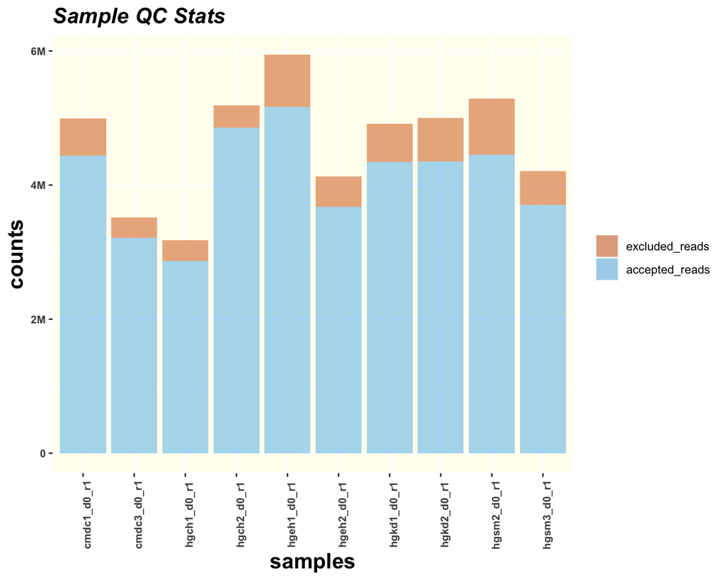

| Group | Sample | Accepted Reads | % Accepted Reads | Excluded Reads | % Excluded Reads | Total Reads | Pass Threshold | Pass |
| --- | --- | --- | --- | --- | --- | --- | --- | --- |
| chr14_95103285_95103579_minus | cmdc1_d0_r1 | 4438983 | 88.9 | 552649 | 11.1 | 4991632 | 1000000 | True |
| chr14_95103285_95103579_minus | cmdc3_d0_r1 | 3217383 | 91.5 | 299204 | 8.5 | 3516587 | 1000000 | True |
| chr14_95103285_95103579_minus | hgch1_d0_r1 | 2870324 | 90.3 | 307358 | 9.7 | 3177682 | 1000000 | True |
| chr14_95103285_95103579_minus | hgch2_d0_r1 | 4854461 | 93.5 | 335662 | 6.5 | 5190123 | 1000000 | True |
| chr14_95103285_95103579_minus | hgeh1_d0_r1 | 5164235 | 86.8 | 782971 | 13.2 | 5947206 | 1000000 | True |
| chr14_95103285_95103579_minus | hgeh2_d0_r1 | 3672915 | 88.9 | 456316 | 11.1 | 4129231 | 1000000 | True |
| chr14_95103285_95103579_minus | hgkd1_d0_r1 | 4342239 | 88.3 | 572612 | 11.7 | 4914851 | 1000000 | True |
| chr14_95103285_95103579_minus | hgkd2_d0_r1 | 4350836 | 87 | 647759 | 13 | 4998595 | 1000000 | True |
| chr14_95103285_95103579_minus | hgsm2_d0_r1 | 4452094 | 84.2 | 835673 | 15.8 | 5287767 | 1000000 | True |
| chr14_95103285_95103579_minus | hgsm3_d0_r1 | 3705849 | 88 | 505849 | 12 | 4211698 | 1000000 | True |

#### 2.2.4. Accepted Reads

Displays the percentage of library reads vs non-library reads (ie. Reference, PAM and Unmapped) for Accepted Reads.

- **Library Reads**: Percentage reads mapping to template oligo sequences, including intended variants.
- **Reference Reads**: Percentage reads mapping to Reference.
- **PAM_Reads**: Percentage reads mapping to PAM/Protospacer Protection Edits (PPEs), without intended variant.
- **Unmapped Reads**: Percentage of Unmapped Reads.

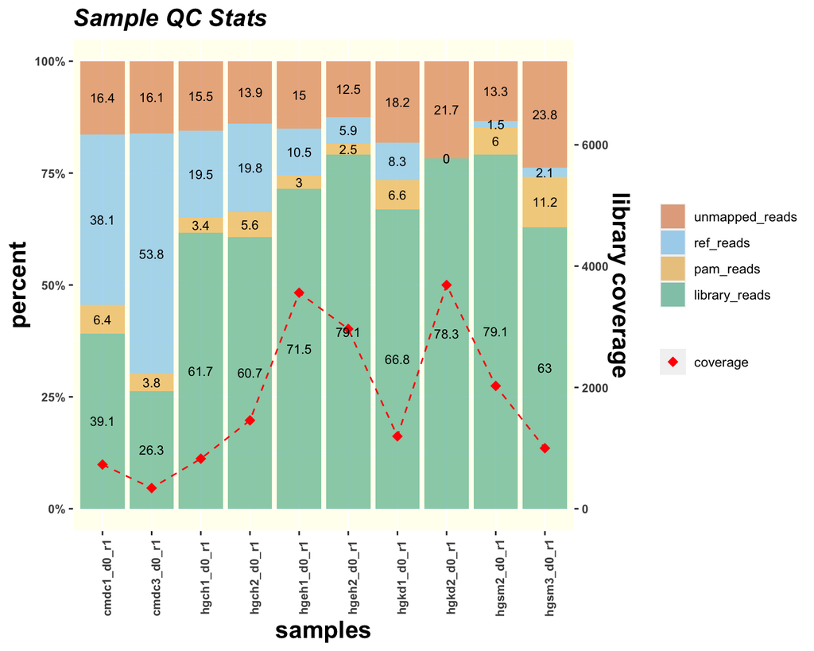

| Group | Sample | % Library Reads | % Reference Reads | % PAM Reads | % Unmapped Reads | Pass Threshold | Pass |
| --- | --- | --- | --- | --- | --- | --- | --- |
| chr14_95103285_95103579_minus | cmdc1_d0_r1 | 39.1 | 38.1 | 6.4 | 16.4 | 40 | False |
| chr14_95103285_95103579_minus | cmdc3_d0_r1 | 26.3 | 53.8 | 3.8 | 16.1 | 40 | False |
| chr14_95103285_95103579_minus | hgch1_d0_r1 | 61.7 | 19.5 | 3.4 | 15.5 | 40 | True |
| chr14_95103285_95103579_minus | hgch2_d0_r1 | 60.7 | 19.8 | 5.6 | 13.9 | 40 | True |
| chr14_95103285_95103579_minus | hgeh1_d0_r1 | 71.5 | 10.5 | 3 | 15 | 40 | True |
| chr14_95103285_95103579_minus | hgeh2_d0_r1 | 79.1 | 5.9 | 2.5 | 12.5 | 40 | True |
| chr14_95103285_95103579_minus | hgkd1_d0_r1 | 66.8 | 8.3 | 6.6 | 18.2 | 40 | True |
| chr14_95103285_95103579_minus | hgkd2_d0_r1 | 78.3 | 0 | 0 | 21.7 | 40 | True |
| chr14_95103285_95103579_minus | hgsm2_d0_r1 | 79.1 | 1.5 | 6 | 13.3 | 40 | True |
| chr14_95103285_95103579_minus | hgsm3_d0_r1 | 63 | 2.1 | 11.2 | 23.8 | 40 | True |

Defines the mean read count per template oligo sequence.

| Group | Sample | Total Library Reads | Total Library Sequences | Library Coverage | Median Coverage | Pass Threshold | Pass |
| --- | --- | --- | --- | --- | --- | --- | --- |
| chr14_95103285_95103579_minus | cmdc1_d0_r1 | 1737012 | 2385 | 728 | 699 | 100 | True |
| chr14_95103285_95103579_minus | cmdc3_d0_r1 | 845205 | 2476 | 341 | 332 | 100 | True |
| chr14_95103285_95103579_minus | hgch1_d0_r1 | 1769460 | 2144 | 825 | 416 | 100 | True |
| chr14_95103285_95103579_minus | hgch2_d0_r1 | 2947475 | 2022 | 1457 | 1471 | 100 | True |
| chr14_95103285_95103579_minus | hgeh1_d0_r1 | 3692836 | 1037 | 3561 | 3062 | 100 | True |
| chr14_95103285_95103579_minus | hgeh2_d0_r1 | 2905179 | 980 | 2964 | 2805.5 | 100 | True |
| chr14_95103285_95103579_minus | hgkd1_d0_r1 | 2902103 | 2429 | 1194 | 902 | 100 | True |
| chr14_95103285_95103579_minus | hgkd2_d0_r1 | 3405056 | 923 | 3689 | 3168.5 | 100 | True |
| chr14_95103285_95103579_minus | hgsm2_d0_r1 | 3521495 | 1739 | 2025 | 2044 | 100 | True |
| chr14_95103285_95103579_minus | hgsm3_d0_r1 | 2334808 | 2338 | 998 | 993 | 100 | True |

#### 2.2.5. Genomic Coverage

Distribution of variants across targeton region based on log2(count+1) values.

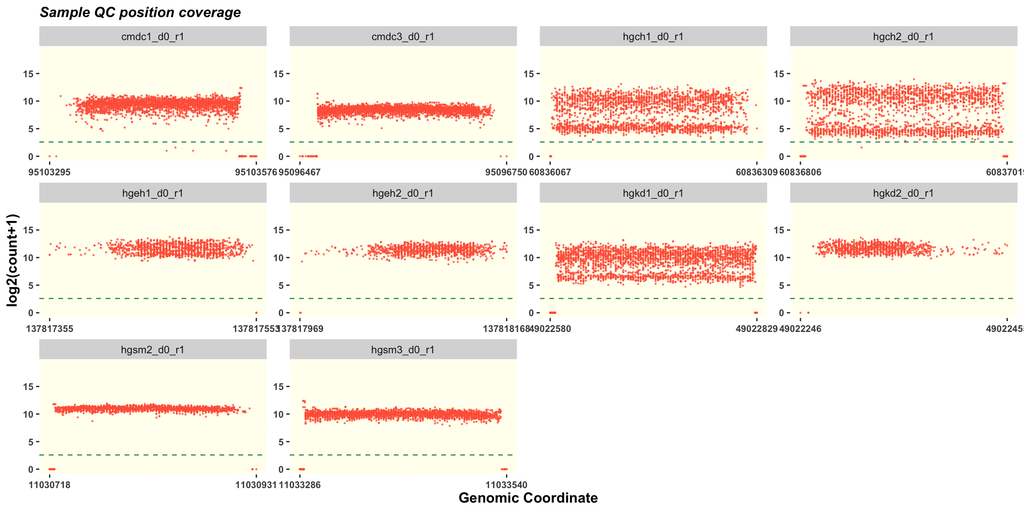

| Group | Sample | Chromosome | Strand | Genomic Start | Genomic End | % Low Abundance | Low Abundance cutoff | Pass Threshold | Pass |
| --- | --- | --- | --- | --- | --- | --- | --- | --- | --- |
| chr14_95103285_95103579_minus | cmdc1_d0_r1 | chr14 | - | 95103285 | 95103579 | 3.94 | 5 | 30 | True |
| chr14_95103285_95103579_minus | cmdc3_d0_r1 | chr14 | - | 95096466 | 95096760 | 2.64 | 5 | 30 | True |
| chr14_95103285_95103579_minus | hgch1_d0_r1 | chr8 | + | 60836044 | 60836339 | 0.38 | 5 | 30 | True |
| chr14_95103285_95103579_minus | hgch2_d0_r1 | chr8 | + | 60836787 | 60837040 | 3.18 | 5 | 30 | True |
| chr14_95103285_95103579_minus | hgeh1_d0_r1 | chr9 | + | 137817327 | 137817577 | 0.29 | 5 | 30 | True |
| chr14_95103285_95103579_minus | hgeh2_d0_r1 | chr9 | + | 137817946 | 137818196 | 0.2 | 5 | 30 | True |
| chr14_95103285_95103579_minus | hgkd1_d0_r1 | chr12 | - | 49022562 | 49022853 | 2.35 | 5 | 30 | True |
| chr14_95103285_95103579_minus | hgkd2_d0_r1 | chr12 | - | 49022233 | 49022483 | 0.44 | 5 | 30 | True |
| chr14_95103285_95103579_minus | hgsm2_d0_r1 | chr19 | + | 11030699 | 11030949 | 1.81 | 5 | 30 | True |
| chr14_95103285_95103579_minus | hgsm3_d0_r1 | chr19 | + | 11033267 | 11033558 | 2.84 | 5 | 30 | True |

## 3. QC Results

Summarising the final results, below are the cutoffs using for PASS/FAIL

[output not shown]

### 3.1. Sample QC Results

| Group | Sample | Gini Coefficient | Total Reads | % Missing Variants | Accepted Reads | % Mapping Reads | % Reference Reads | % Library Reads | Library Coverage | % R1 Adatpor | % R2 Adaptor |
| --- | --- | --- | --- | --- | --- | --- | --- | --- | --- | --- | --- |
| chr14_95103285_95103579_minus | cmdc1_d0_r1 | 0.314 | True | False | True | True | False | False | True | 0.3183 | 0 |
| chr14_95103285_95103579_minus | cmdc3_d0_r1 | 0.329 | True | False | True | True | False | False | True | 0.3211 | 0 |
| chr14_95103285_95103579_minus | hgch1_d0_r1 | 0.645 | True | True | True | True | False | True | True | 0.315 | 0 |
| chr14_95103285_95103579_minus | hgch2_d0_r1 | 0.667 | True | False | True | True | False | True | True | 0.3312 | 0 |
| chr14_95103285_95103579_minus | hgeh1_d0_r1 | 0.351 | True | True | True | True | False | True | True | 0.3281 | 0 |
| chr14_95103285_95103579_minus | hgeh2_d0_r1 | 0.271 | True | True | True | True | True | True | True | 0.3307 | 0 |
| chr14_95103285_95103579_minus | hgkd1_d0_r1 | 0.569 | True | False | True | True | True | True | True | 0.3206 | 0 |
| chr14_95103285_95103579_minus | hgkd2_d0_r1 | 0.291 | True | True | True | True | True | True | True | 0.3284 | 0 |
| chr14_95103285_95103579_minus | hgsm2_d0_r1 | 0.192 | True | False | True | True | True | True | True | 0.3304 | 0 |
| chr14_95103285_95103579_minus | hgsm3_d0_r1 | 0.309 | True | False | True | True | True | True | True | 0.3188 | 0 |